# AFM 346 Final Project - Top Performing Model

Derek Shat

12/15/2021

```r
library(tidyverse)
library(readxl)
library(tidymodels)
library(GGally)
library(knitr)
library(doParallel)
library(tictoc)
library(janitor)
```

```r
credit_raw <- read_xls("default of credit card clients.xls", skip = 1)

credit_dt <- credit_raw %>%
  clean_names() %>%
        select(default = default_payment_next_month,
               everything()) %>%
  mutate(across(.cols = c('default','sex',
                          'education', 'marriage',
                          matches('pay_[0-9]')),
                as_factor))

set.seed(123)
credit_split <- initial_split(credit_dt, prop = 0.7, strata = default)
credit_train <- training(credit_split)
credit_test <- testing(credit_split)
set.seed(456)
credit_folds <- credit_train %>%
  vfold_cv(v = 5, repeats = 5, strata = default)

perf_meas <- metric_set(kap,f_meas,roc_auc,mn_log_loss)
```

# Top Performing Model

The top performing model chosen was the single layer neural net. This model was chosen because it is a more complex model and also because neural networks were said to be “the only one that can accurately estimate the real probability of default” in the description of the data set. Neural networks use a hierarchy of models that try to separate defaults from non-defaults that use functions and iteratively changing weights to try to classify the data correctly.

In addition to the preprocessing steps from low-complexity model, there is also a step to create dummy variables representing whether the credit balance is currently positive or negative, as well as a Yeo-Johnson transformation step.

The hyperparameters are hidden_units, penalty, and epochs. hidden_units specifies the number of hidden units in the layer, penalty is the same as in logistic regression, and epochs is the number of training iterations.

```r
top_recipe <-
  recipe(default~., data = credit_train) %>%
  step_dummy(sex:pay_6, -age) %>%
  step_zv(all_numeric_predictors(), -all_outcomes()) %>%
  step_normalize(all_numeric_predictors(), -all_outcomes())%>%
  step_mutate(prop_bill1 = pay_amt1/(bill_amt1 + 1),
              prop_bill2 = pay_amt2/(bill_amt2 + 1),
              prop_bill3 = pay_amt3/(bill_amt3 + 1),
              prop_bill4 = pay_amt4/(bill_amt4 + 1),
              prop_bill5 = pay_amt5/(bill_amt5 + 1),
              prop_bill6 = pay_amt6/(bill_amt6 + 1),
              bill_dummy_1 = ifelse(bill_amt1 >= 0, 1, 0),
              bill_dummy_2 = ifelse(bill_amt2 >= 0, 1, 0),
              bill_dummy_3 = ifelse(bill_amt3 >= 0, 1, 0),
              bill_dummy_4 = ifelse(bill_amt4 >= 0, 1, 0),
              bill_dummy_5 = ifelse(bill_amt5 >= 0, 1, 0),
              bill_dummy_6 = ifelse(bill_amt6 >= 0, 1, 0)) %>%
  step_YeoJohnson(all_numeric_predictors(), -all_outcomes()) %>%
  step_corr(bill_amt1:bill_amt6, -all_outcomes())


top_mod <-
  mlp(hidden_units = tune(),
      penalty = tune(),
      epochs = tune()) %>%
  set_mode('classification') %>%
  set_engine('nnet')

nn_grid <- grid_latin_hypercube(hidden_units(range=c(2,4)),
                                penalty(range=c(-10,-8)),
                                epochs(range = c(200, 218)),
                                size = 20)

top_wf <-
  workflow() %>%
  add_recipe(top_recipe) %>%
  add_model(top_mod)

all_cores <- parallel::detectCores(logical = FALSE)
cl <- makePSOCKcluster(all_cores)
registerDoParallel(cl)

tune_ctrl <- control_resamples(save_pred = TRUE)

tic()
top_res <-
  top_wf %>%
    tune_grid(credit_folds,
              grid = nn_grid,
              metrics = perf_meas,
              control = tune_ctrl)
toc()
```

```
## 1776.82 sec elapsed
```

```r
stopCluster(cl)

show_best(top_res, metric = "kap") %>% kable(digits = 3)
```

| hidden_units | penalty | epochs | .metric | .estimator | mean | n | std_err | .config |
| --- | --- | --- | --- | --- | --- | --- | --- | --- |
| 2 | 0 | 217 | kap | binary | 0.389 | 25 | 0.005 | Preprocessor1_Model15 |
| 2 | 0 | 206 | kap | binary | 0.385 | 25 | 0.004 | Preprocessor1_Model07 |
| 2 | 0 | 203 | kap | binary | 0.381 | 25 | 0.004 | Preprocessor1_Model04 |
| 2 | 0 | 215 | kap | binary | 0.379 | 25 | 0.006 | Preprocessor1_Model17 |
| 3 | 0 | 201 | kap | binary | 0.376 | 25 | 0.006 | Preprocessor1_Model19 |

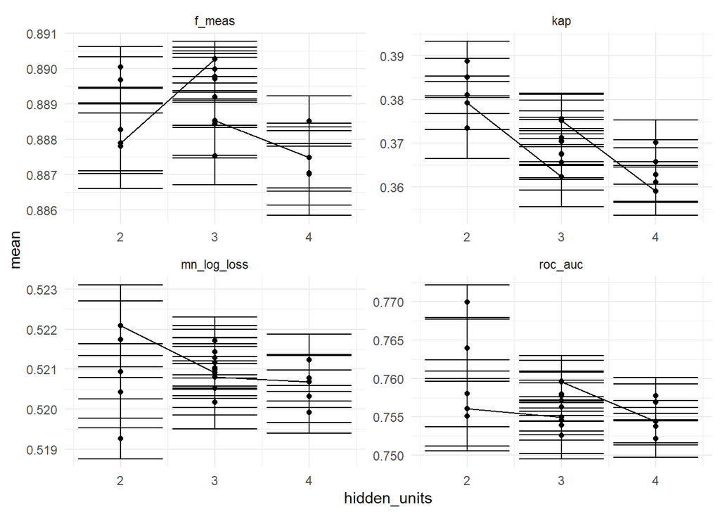

```r
top_res %>%
  collect_metrics() %>%
  ggplot(aes(x = hidden_units, y = mean)) +
  geom_point() +
  geom_line() +
  geom_errorbar(
    aes(ymin = mean - std_err,
        ymax = mean + std_err)) +
  facet_wrap(~.metric, scales = 'free', ncol = 2) +
  theme_minimal()
```

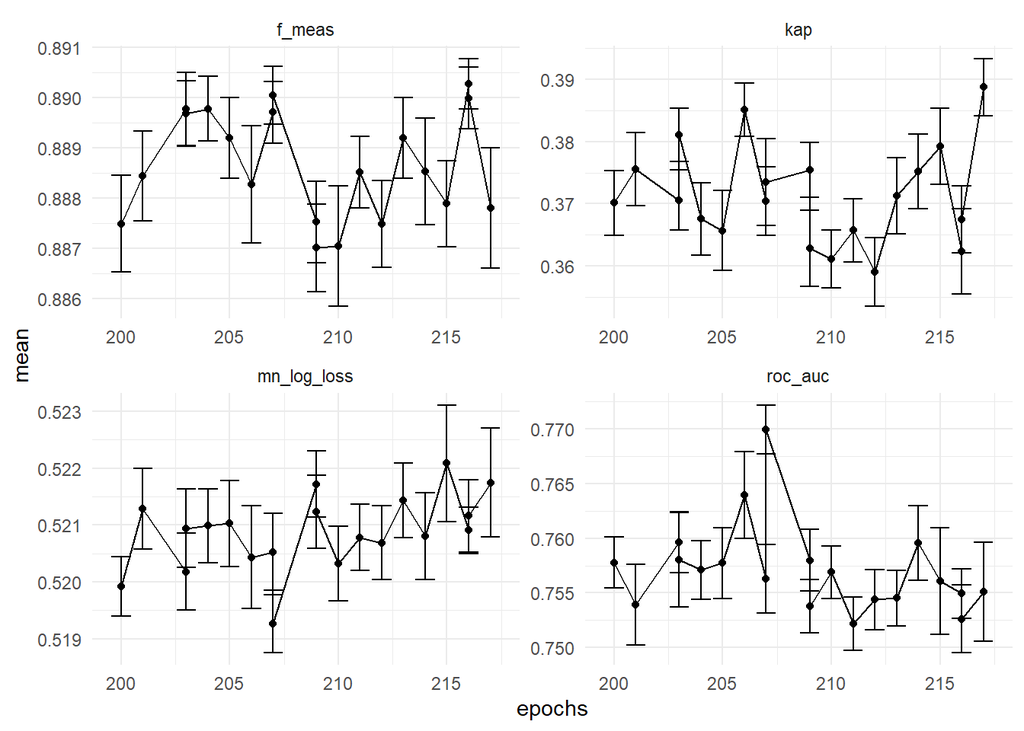

```r
top_res %>%
  collect_metrics() %>%
  ggplot(aes(x = epochs, y = mean)) +
  geom_point() +
  geom_line() +
  geom_errorbar(
    aes(ymin = mean - std_err,
        ymax = mean + std_err)) +
  facet_wrap(~.metric, scales = 'free', ncol = 2) +
  theme_minimal()
```

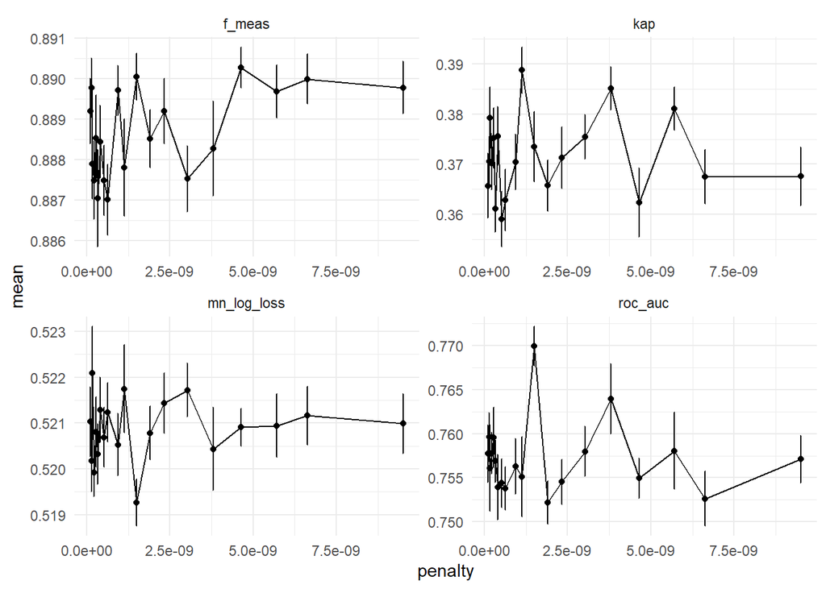

```r
top_res %>%
  collect_metrics() %>%
  ggplot(aes(x = penalty, y = mean)) +
  geom_point() +
  geom_line() +
  geom_errorbar(
    aes(ymin = mean - std_err,
        ymax = mean + std_err)) +
  facet_wrap(~.metric, scales = 'free', ncol = 2) +
  theme_minimal()
```

```r
wf_top_final <- top_wf %>%
  finalize_workflow(select_best(top_res, metric = "kap"))

top_fit <- wf_top_final %>%
  fit(credit_train)

save(top_fit, top_res, top_wf, file = 'top_res.Rda')
```